# Влияние витамина С на поддержание жизни больных онкологическими заболеваниями

С. А. Бердыева

9 июля 2021

## Введение

Исследования применения витамина C в лечении онкологических заболеваний имеют большое значение для медицинской науки, так как в нем может заключаться эффективное средство терапии данного комплекса заболеваний[3]. В представленном проекте внимание исследователей было сконцентрировано на продлении жизни уже болеющих раком пациентов, и главный акцент был сделан на эффективности витамина С при поддержании жизни больных раком груди по сравнению с этим же показателем для больных другими видами онкологических заболеваний (раком желудка, бронхов, кишечника и яичников). Таким образом, независимой переменной выступил вид рака, а зависимой время выживания с момента диагностировния болезни и начала приема витамина С. Главной гипотезой исследователей было утверждение о наличии значимых различий в продолжительности периода, пока человек жив во время приема аскорбата (витамина С), у больных раком груди и у больных другими видами рака. При вычислениях уровень значимости был равен 0.05.

## Материалы и методы.

Все расчеты проводились в среде R с использованием пакетов readxl, car, ggplot2 и cowplot. Данные были получены в документе формата .xlsx неупорядоченными по алфавиту в переменной “Орган”. Значения этой переменной превратили в факторы.

```r
library(readxl)
cancer_data<-read_excel('C:/Users/Sofiya/Documents/R/Coursera/Linmodr/data/cancer.xlsx')
sum(is.na(cancer_data))
```

```
## [1] 0
```

```r
#Пропущенных значений нет.
cancer_data$Organ <- factor(cancer_data$Organ,
                            levels = c('Breast', 'Bronchus', 'Colon','Ovary', 'Stomach'),
                            ordered=FALSE)
```

Проведено четыре двухвыборочных t-теста Уэлча [4], в каждом из которых последовательно сравнивается время выживания больных раком груди и больных раком бронхов, кишечника, яичников и желудка. Для того, чтобы оценить применимость этого теста, проверили соблюдение необходимых критериев:

1. Наблюдения независимы друг от друга - выполняется, так как отбор пациентов проводился из определенного множества неизлечимо больных (генеральная совокупность) случайным образом и с учетом наличия необходимой информации об истории болезни [2]. Также при статистической обработке предполагалось, что у каждого из больных был только один вид ракового заболевания.
2. Выборки независимы друг от друга - выполняется, поскольку данные в каждой из них брали у разных пациентов.
3. Объем выборки достаточно велик или величины распределены нормально:

```r
#Объемы выборок:
table(cancer_data$Organ)
```

```
##
##   Breast Bronchus    Colon    Ovary  Stomach
##       11       17       17        6       13
```

Как можно видеть, объем каждой из выборок мал. При построении квантильных графиков изначальных распределений было обнаружено большое количество выбросов, поэтому принято решение проводить расчеты над величинами, равными квадратному корню из имеющихся данных. Это позволит привести выборки к виду, более близкому к нормальному (рис. 1), при этом никак не повлияв на результаты статистических вычислений.

```r
# Создадим переменные с соответствующими значениями времени выживания для каждого из видов рака
surv_breast <- c(cancer_data$Survival[cancer_data$Organ=='Breast'])
surv_bronchus <- c(cancer_data$Survival[cancer_data$Organ=='Bronchus'])
surv_colon <- c(cancer_data$Survival[cancer_data$Organ=='Colon'])
surv_ovary <- c(cancer_data$Survival[cancer_data$Organ=='Ovary'])
surv_stomach <- c(cancer_data$Survival[cancer_data$Organ=='Stomach'])
library(car)
# Вычислим квадратный корень из всех значений и занесем их в новые переменные
sq_surv_breast <- sqrt(surv_breast)
sq_surv_bronchus <-sqrt(surv_bronchus)
sq_surv_colon <- sqrt(surv_colon)
sq_surv_ovary <- sqrt(surv_ovary)
sq_surv_stomach <- sqrt(surv_stomach)
```

```r
# Построим квантильные графики полученных распределений для проверки на нормальность
qq_sqbreast <- qqPlot(sq_surv_breast,main = 'Рак груди',
                      xlab = 'Квантили нормального распределения',
                      ylab = 'Корень из числа дней, прожитых пациентом')
qq_sqbron <- qqPlot(sq_surv_bronchus,main = 'Рак бронхов',
                    xlab = 'Квантили нормального распределения',
                    ylab = 'Корень из числа дней, прожитых пациентом')
qq_sqcol <- qqPlot(sq_surv_colon,main = 'Рак кишечника',
                   xlab = 'Квантили нормального распределения',
                   ylab = 'Корень из числа дней, прожитых пациентом')
qq_sqova <- qqPlot(sq_surv_ovary,main = 'Рак яичников',
                   xlab = 'Квантили нормального распределения',
                   ylab = 'Корень из числа дней, прожитых пациентом')
qq_sqstom <- qqPlot(sq_surv_stomach,main = 'Рак желудка',
                    xlab = 'Квантили нормального распределения',
                    ylab = 'Корень из числа дней, прожитых пациентом')
```

**Рис.1. Квантильные графики распределений значений квадратного корня из числа дней, прожитых больными различными видами рака.**

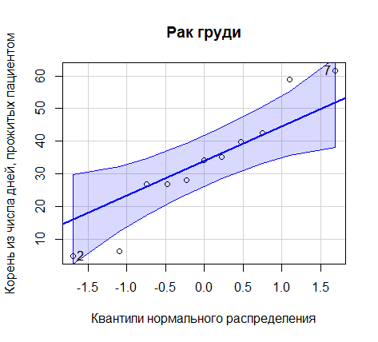

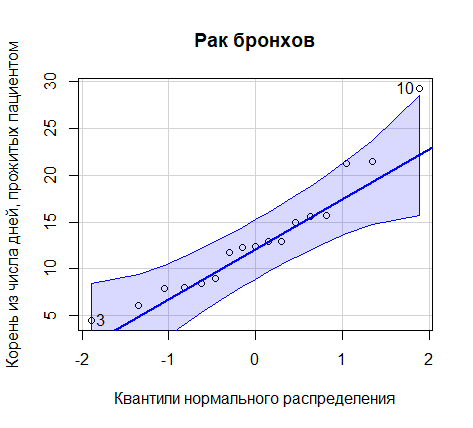

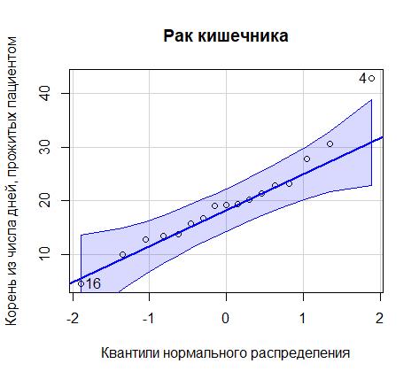

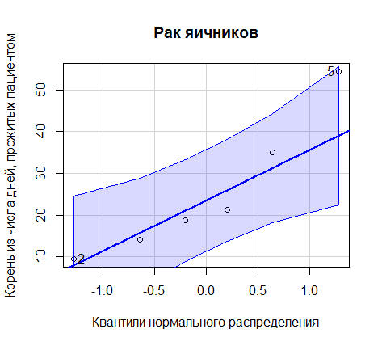

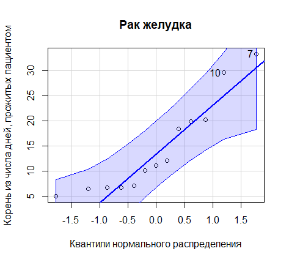

После завершения каждого из тестов проведена коррекция методом Бенджамини-Хохберга (FDR)[5].

## Расчеты.

```r
#Соберем новые значения переменных в новый и упорядоченный датафрейм.
cancer_sq_data <- data.frame (survival = c(sq_surv_breast,sq_surv_bronchus,sq_surv_colon,sq_surv_ovary,sq_surv_stomach),
                              organ=sort(cancer_data$Organ))
##Тестирования. Значения p-value будем сохранять в новые переменные----
#Рак груди и рак бронхов-----
tt_brst_brnchs <- t.test(survival[cancer_sq_data$organ=='Breast'|cancer_sq_data$organ=='Bronchus']~organ[cancer_sq_data$organ=='Breast'|cancer_sq_data$organ=='Bronchus'], data=cancer_sq_data)
tt_brst_brnchs
```

```
##
##  Welch Two Sample t-test
##
## data:  survival[cancer_sq_data$organ == "Breast" | cancer_sq_data$organ == "Bronchus"] by organ[cancer_sq_data$organ == "Breast" | cancer_sq_data$organ == "Bronchus"]
## t = 3.5507, df = 11.6, p-value = 0.004197
## alternative hypothesis: true difference in means is not equal to 0
## 95 percent confidence interval:
##   7.677628 32.307820
## sample estimates:
##   mean in group Breast mean in group Bronchus
##               33.19825               13.20553
```

```r
p_brst_brnchs <- tt_brst_brnchs$p.value
#Рак груди и рак кишечника-----
tt_brst_cln <- t.test(survival[cancer_sq_data$organ=='Breast'|cancer_sq_data$organ=='Colon']~organ[cancer_sq_data$organ=='Breast'|cancer_sq_data$organ=='Colon'],data=cancer_sq_data)
tt_brst_cln
```

```
##
##  Welch Two Sample t-test
##
## data:  survival[cancer_sq_data$organ == "Breast" | cancer_sq_data$organ == "Colon"] by organ[cancer_sq_data$organ == "Breast" | cancer_sq_data$organ == "Colon"]
## t = 2.3308, df = 13.105, p-value = 0.03637
## alternative hypothesis: true difference in means is not equal to 0
## 95 percent confidence interval:
##   1.002005 26.130184
## sample estimates:
## mean in group Breast  mean in group Colon
##             33.19825             19.63216
```

```r
p_brst_cln <- tt_brst_cln$p.value
#Рак груди и рак яичников----
tt_brst_ov <- t.test(survival[cancer_sq_data$organ=='Breast'|cancer_sq_data$organ=='Ovary']~organ[cancer_sq_data$organ=='Breast'|cancer_sq_data$organ=='Ovary'],data=cancer_sq_data)
tt_brst_ov
```

```
##
##  Welch Two Sample t-test
##
## data:  survival[cancer_sq_data$organ == "Breast" | cancer_sq_data$organ == "Ovary"] by organ[cancer_sq_data$organ == "Breast" | cancer_sq_data$organ == "Ovary"]
## t = 0.87766, df = 11.148, p-value = 0.3986
## alternative hypothesis: true difference in means is not equal to 0
## 95 percent confidence interval:
##  -11.46088  26.70418
## sample estimates:
## mean in group Breast  mean in group Ovary
##             33.19825             25.57660
```

```r
p_brst_ov <- tt_brst_ov$p.value
#Рак груди и рак желудка----
tt_brst_stom <- t.test(survival[cancer_sq_data$organ=='Breast'|cancer_sq_data$organ=='Stomach']~organ[cancer_sq_data$organ=='Breast'|cancer_sq_data$organ=='Stomach'],data=cancer_sq_data)
tt_brst_stom
```

```
##
##  Welch Two Sample t-test
##
## data:  survival[cancer_sq_data$organ == "Breast" | cancer_sq_data$organ == "Stomach"] by organ[cancer_sq_data$organ == "Breast" | cancer_sq_data$organ == "Stomach"]
## t = 3.1367, df = 14.379, p-value = 0.007085
## alternative hypothesis: true difference in means is not equal to 0
## 95 percent confidence interval:
##   5.979589 31.638334
## sample estimates:
##  mean in group Breast mean in group Stomach
##              33.19825              14.38929
```

```r
p_brst_stom <- tt_brst_stom$p.value
##Поправка на множественное тестирование----
p_corr <- p.adjust(p=c(p_brst_brnchs,p_brst_cln,p_brst_ov,p_brst_stom), method='fdr')
p_corr
```

```
## [1] 0.01416971 0.04848905 0.39864771 0.01416971
```

## Результаты и обсуждение.

```r
p_corr
```

```
## [1] 0.01416971 0.04848905 0.39864771 0.01416971
```

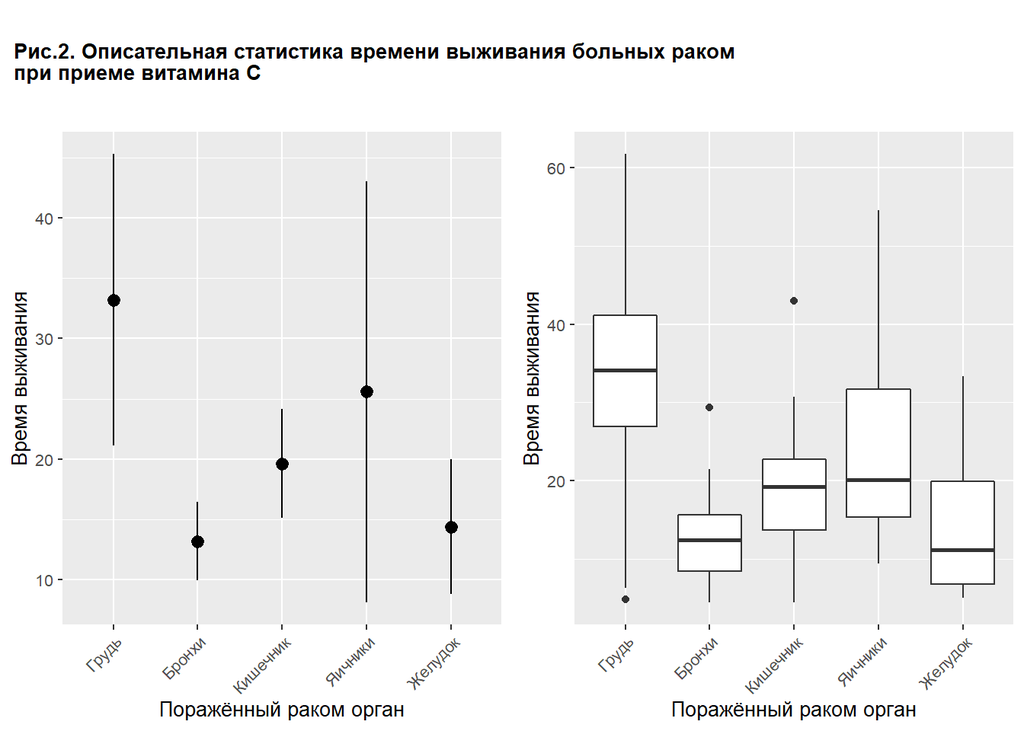

```r
library(ggplot2)
library(cowplot)
theme_set(theme_grey(base_size = 10))
#График с доверительными интервалами
gg_ptr <- ggplot(data=cancer_sq_data, aes (x= organ, y= survival)) +
         stat_summary(geom= 'pointrange',
                      fun.data = mean_cl_normal) +
         scale_colour_brewer( palette = 'Set3') + labs(x = 'Поражённый раком орган', y = 'Время выживания')+ scale_x_discrete(labels=c('Грудь','Бронхи','Кишечник','Яичники','Желудок'))+ theme(legend.position ="none",
                axis.text.x= element_text(angle = 45, hjust = 1),
                axis.title = element_text(size=10) )
#Боксплот
 gg_bxplt <- ggplot(data=cancer_sq_data) +
             geom_boxplot(aes(x=organ, y=survival))+
             theme(legend.position ="none",
                   axis.text.x= element_text(angle = 45, hjust = 1) )+
             labs(x = 'Поражённый раком орган',
                  y = 'Время выживания') +
             scale_x_discrete(labels=c('Грудь','Бронхи','Кишечник','Яичники','Желудок'))
 title <- ggdraw() +
   draw_label("Рис.2. Описательная статистика времени выживания больных раком\nпри приеме витамина С",
     fontface = 'bold', x = 0,
hjust=0 , size=10  )+
   theme(plot.margin = margin(0, 0, 0, 7)
   )
plot_grid_1 <- plot_grid(gg_ptr, gg_bxplt)
plot_grid_2 <- plot_grid(title,plot_grid_1, ncol = 1,rel_heights = c(0.2, 1))
plot_grid_2
```

1. Гипотезу об отсутствии различий между временем выживания больных раком груди и больных раком бронхов следует отклонить, так как полученное значение p (0.01417) меньше 0.05. Соответственно, альтернативная гипотеза верна и имеются значимые различия.
2. Гипотезу об отсутствии различий между временем выживания больных раком груди и больных раком кишечника также следует отклонить, так как полученное значение p (0.04849) меньше 0.05. Таким образом, альтернативная гипотеза верна и имеются значимые различия.
3. Гипотезу об отсутствии различий между временем выживания больных раком груди и больных раком яичников также следует принять, так как полученное значение p (0.39865) больше 0.05. По этой причине альтернативная гипотеза неверна. Стоит отметить, что объем выборки больных раком яичников был наименьшим, что наталкивает на мысль о том, что не следует делать поспешных выводов на ее основе.
4. Гипотезу об отсутствии различий между временем выживания больных раком груди и больных раком желудка следует отклонить, так как полученное значение p (0.01417) меньше 0.05. Альтернативная гипотеза верна и имеются значимые различия.

## Выводы.

Три из четырех альтернативных гипотез о наличии различий подтвердились, а существенное абсолютное превосходство среднего значения времени выживания в выборке больных раком груди говорит о том, что применение витамина С при лечении онкологических заболеваний наиболее эффективно именно для этой группы пациентов. О том, насколько близок этот показатель по значению у людей с раком яичников, мы бы не выдвигали никаких предположений, поскольку выборки из шести человек недостаточно для адекватной оценки.

## Список литературы

[1] Arranging plots in a grid. (n.d.). Retrieved 10 July 2021, from https://wilkelab.org/cowplot/articles/plot_grid.html

[2] Cameron, E., & Pauling, L. (1978). Supplemental ascorbate in the supportive treatment of cancer: Reevaluation of prolongation of survival times in terminal human cancer. Proceedings of the National Academy of Sciences of the United States of America, 75(9), 4538–4542. https://doi.org/10.1073/pnas.75.9.4538

[3] Витамин С оказался способным побеждать неизлечимые формы рака: Наука: Наука и техника: Lenta.ru. (n.d.). Retrieved 10 July 2021, from https://lenta.ru/news/2015/11/06/vitaminc/

[4] Классические методы статистики: T-критерий Стьюдента. (n.d.). R: Анализ и Визуализация Данных. Retrieved 10 July 2021, from https://r-analytics.blogspot.com/2012/03/t.html

[5] Процедуры множественных проверок гипотез: Метод Беньямини-Хохберга. (n.d.). R: Анализ и Визуализация Данных. Retrieved 10 July 2021, from https://r-analytics.blogspot.com/2013/11/blog-post.html